# Séance de travaux dirigés 8

#### [Questions de cours](http://francoio.github.io/html/CM7.html)

- Rappeler le principe d’une méthode de Monte-Carlo.

##### Exercice 1

Soient $(U_n)$ et $(V_n)$ deux suites de variables aléatoires de loi uniforme sur l’intervalle $[0,1]$. On suppose que ces variables aléatoires sont indépendantes dans leur ensemble. On pose

$\forall n \geq 1\; , \quad \left\{ \begin{array}{ccl} X_n & = & 1 \quad \mbox{si } U_n^2 + V_n^2 \leq 1 \\ & & 0 \quad \mbox{sinon} \end{array} \right.$

et $Z_n = 4 ( X_1 + \dots + X_n )/ n$.

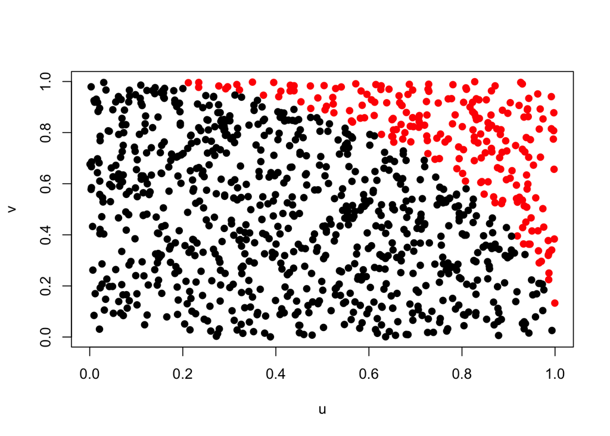

```r
n <- 1000
u <- runif(n)
v <- runif(n)
plot(u, v, col = 1 +  (u^2 + v^2 > 1), pch = 19)
```

##### Question 1

- Déterminer la loi de la variable $X_n$.
- Calculer la variance de $Z_n$ et montrer que la suite $(Z_n)$ converge vers $\pi$.

##### Question 2

- A l’aide de l’inégalité de Chebishev, déterminer un entier $n_0$ tel que

$\forall n \geq n_0 \; , \quad \mbox{P}(|Z_n - \pi| > \epsilon) \leq \alpha \; .$

- Ecrire un algorithme qui retourne une valeur approchée de $\pi$ à $10^{-4}$ près, avec une probabilité supérieure à $0.95$.

```r
n <- 100000 #n'est pas la valeur demandée
u <- runif(n)
v <- runif(n)
4*mean(u^2 + v^2 < 1)
```

```
## [1] 3.14084
```

##### Question 3

On multiplie la variable $Z_n$ par $\sqrt{n}$.

- Calculer la variance de la variable $\sqrt{n}(Z_n - \pi)$. Cette variance converge-t-elle vers 0 ? Vers une constante ?
- Quelle loi connue fournit une bonne approximation de la loi de $\sqrt{n} (Z_n - \pi)$ ?

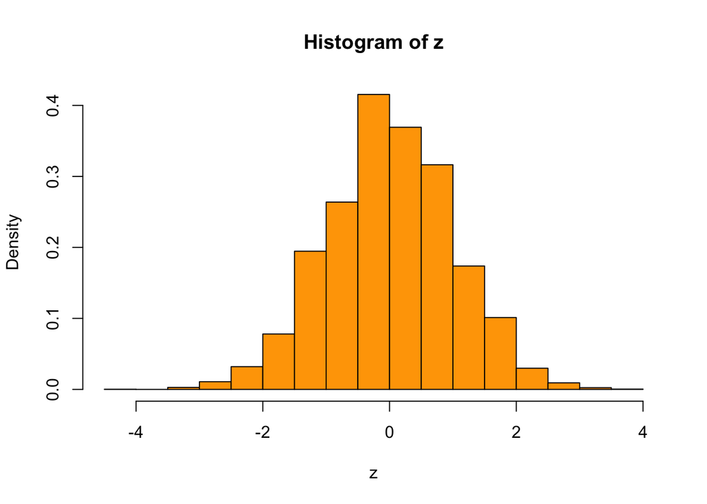

```r
rzn <- function(m=1,n=1000){
  zn <- NULL
  for (i in 1:m){
    u <- runif(n)
    v <- runif(n)
    zn <- c(zn, 4*mean(u^2 + v^2 < 1) )
  }
  return(zn)
}
z  <- sqrt(1000)*(rzn(10000) - pi)/sqrt(pi*(4-pi))
hist(z, prob = TRUE, col = "orange")
```

#### Exercice 2

On considère une suite $(U_n)$ de variables aléatoires indépendantes de loi uniforme sur $(0,1)$ et la fonction $\forall u \in (0,1), \quad \varphi (u) = \sqrt{(1 - u) u^3} .$

##### Question 1

Pour tout $n\geq 1$, on pose $Y_n = \frac1n \sum_{i = 1}^n \varphi (U_i).$

- Montrer que la suite $Y_n$ converge, au sens de la loi des grands nombres, vers la limite ${\cal I}$ définie ci-dessous

${\cal I} = \int_0^1 \varphi (u) du \, .$

On admettra que ${\cal I} = \pi / 16$.

##### Question 2

- Calculer la variance de la variable aléatoire $Y_n$.
- Soit $\epsilon = 10^{-3}$. A l’aide du théorème de Chebyshev, donner une estimation du rang $n$ à partir duquel on peut considérer que

${\rm P} ( | Y_n - {\cal I}| < \epsilon ) \geq 0.95 \, .$

##### Question 2

On considère la loi de densité $f(v)$ définie sur l’intervalle $(0,1)$ de la manière suivante $\forall v \in (0,1), \quad f(v) = 6 v(1 - v) .$

Soit $(V_n)$ une suite de variables aléatoires indépendantes, de loi de densité $f(v)$. Pour tout $n\geq 1$, on pose $Z_n = \frac1n \sum_{i = 1}^n \frac{ \varphi (V_i) }{f(V_i)}.$

- Montrer que la suite $Z_n$ converge vers ${\cal I}$.
- Comparer la variance de la variable aléatoire $Z_n$ à celle de la variable $Y_n$.

##### Question 3

- Proposer deux algorithmes de calcul de l’intégrale ${\cal I}$ s’appuyant sur les questions précédentes.
- Lequel vous semble le plus précis des deux pour $n$ appels du générateur aléatoire ? Justifier.

```r
phi <- function(u){ sqrt((1-u)*u^3)}
# Algorithme 1
n <- 1000000
mean(y <- phi(runif(n)))
```

```
## [1] 0.1965205
```

```r
pi/16
```

```
## [1] 0.1963495
```

```r
var(y)
```

```
## [1] 0.0114485
```

```r
# Algorithme 2
n <- 1000000
f <- function(v){dbeta(v,2,2)}
u <- rbeta(n, 2, 2)
mean(z <- phi(u)/f(u))
```

```
## [1] 0.1961783
```

```r
pi/16
```

```
## [1] 0.1963495
```

```r
var(z)
```

```
## [1] 0.01670584
```

##### Question 4

Soit $1\leq \alpha \leq 3$. On considère désormais que $f(v)$ appartient à la famille de densités $f_{\alpha}(v)$ définies sur l’intervalle $(0,1)$ de la manière suivante $\forall v \in (0,1), \quad f_{\alpha}(v) = c_{\alpha} v^{\alpha} (1 - v) .$ (loi beta($\alpha$+1,2))

- Montrer (ou admettre) que la constante $c_{\alpha}$ est égale à $(\alpha + 2)(\alpha +1)$.
- A quel choix de $\alpha$ correspond l’algorithme de calcul de ${\cal I}$ le plus précis ?
- La précision est-elle supérieure à celle de l’algorithme s’appuyant sur la question 1) ?